# Lecture 3: Data Exploration and Visualization Workshop

Sharon Tan

2/2/2021

## Building Dashboards for Bank Credit Risk Analyses

**A few things to do before you start working on the Dashboards.**

*- Start by installing the packges you need. I will set message=FALSE and warning=FALSE so they will not show up in the HTML output.*

```r
#install.packages("dplyr") #only need to run this code once to install the package
library("dplyr") #need to call the libary before you use the package
#install.packages("tidyr")
library("tidyr")
library("rpivotTable")
library("knitr")
```

The worksheet Base Data in the Excel file Bank Credit Risk Data provides information about 425 bank customers who had applied for loans. Each of the column is defined as follows:

- `Loan Purpose` : Type of purpose for the loan applied
- `Checking` : Checking account balance
- `Savings` : Savings account balance
- `Months Customer`: Number of months has been a customer of the bank
- `Months Employed`: Number of months in employment
- `Gender`: Gender
- `Marital Status`: Marital status
- `Age`: Age in years
- `Housing`: Housing type
- `Years`: Number of years at current residence
- `Job`: Job type
- `Credit Risk`: Credit-risk classification by the bank

*- Be sure to set working directory and import the datafile.*

```r
#put in your working directory folder pathname
setwd("~/Dropbox/Teaching/TBA2102/AY2021/Inclass Lecture/Lecture 3")
#import excel file into RStudio
library(readxl)
Bank_Credit_Risk_Data <- read_excel("Bank Credit Risk Data.xlsx",
                               sheet = "Base Data", skip = 2)
View(Bank_Credit_Risk_Data)
BD<-Bank_Credit_Risk_Data
```

*- Check that you have entered the data correctly by using the head() and summary() functions.*

```
## # A tibble: 6 x 12
##   `Loan Purpose` Checking Savings `Months Custome… `Months Employe… Gender
##   <chr>             <dbl>   <dbl>            <dbl>            <dbl> <chr>
## 1 Small Applian…        0     739               13               12 M
## 2 Furniture             0    1230               25                0 M
## 3 New Car               0     389               19              119 M
## 4 Furniture           638     347               13               14 M
## 5 Education           963    4754               40               45 M
## 6 Furniture          2827       0               11               13 M
## # … with 6 more variables: `Marital Status` <chr>, Age <dbl>, Housing <chr>,
## #   Years <dbl>, Job <chr>, `Credit Risk` <chr>
```

```
##  Loan Purpose          Checking        Savings      Months Customer
##  Length:425         Min.   :    0   Min.   :    0   Min.   : 5.0
##  Class :character   1st Qu.:    0   1st Qu.:  228   1st Qu.:13.0
##  Mode  :character   Median :    0   Median :  596   Median :19.0
##                     Mean   : 1048   Mean   : 1813   Mean   :22.9
##                     3rd Qu.:  560   3rd Qu.:  921   3rd Qu.:28.0
##                     Max.   :19812   Max.   :19811   Max.   :73.0
##  Months Employed    Gender          Marital Status          Age
##  Min.   :  0.0   Length:425         Length:425         Min.   :18.0
##  1st Qu.:  6.0   Class :character   Class :character   1st Qu.:26.0
##  Median : 20.0   Mode  :character   Mode  :character   Median :32.0
##  Mean   : 31.9                                         Mean   :34.4
##  3rd Qu.: 47.0                                         3rd Qu.:41.0
##  Max.   :119.0                                         Max.   :73.0
##    Housing              Years          Job            Credit Risk
##  Length:425         Min.   :1.00   Length:425         Length:425
##  Class :character   1st Qu.:2.00   Class :character   Class :character
##  Mode  :character   Median :3.00   Mode  :character   Mode  :character
##                     Mean   :2.84
##                     3rd Qu.:4.00
##                     Max.   :4.00
```

### 1) Customer Profile Dashboard

#### Purpose: To understand the customer profile better. (Assume: customer characteristics of interests are gender, marital status, age, savings)

**Frequency distributions/charts for customer demographics**

```r
#Pie chart for Gender
GenderFreq<-BD%>%count(Gender)
kable(GenderFreq, caption = "Frequency of Bank Customers by Gender")
```

Frequency of Bank Customers by Gender

| Gender | n |
| --- | --- |
| F | 135 |
| M | 290 |

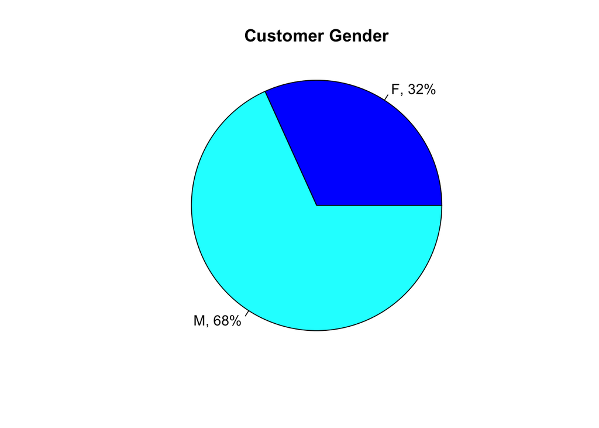

```r
slice.gen <- GenderFreq$n
gen.piepercent <- 100*round(GenderFreq$n/sum(GenderFreq$n),2)
label<-GenderFreq$Gender
label<-paste(label,",",sep="")
label<-paste(label,gen.piepercent) #default of sep=" "
label<-paste(label,"%",sep="")
pie(slice.gen,labels=label, col=c("blue","cyan"),radius=1, main="Customer Gender")
```

```r
#Pie Chart for Marital Status
MSFreq<-BD%>%count(`Marital Status`)
kable(MSFreq, caption = "Frequency of Bank Customers by Marital Status")
```

Frequency of Bank Customers by Marital Status

| Marital Status | n |
| --- | --- |
| Divorced | 156 |
| Married | 36 |
| Single | 233 |

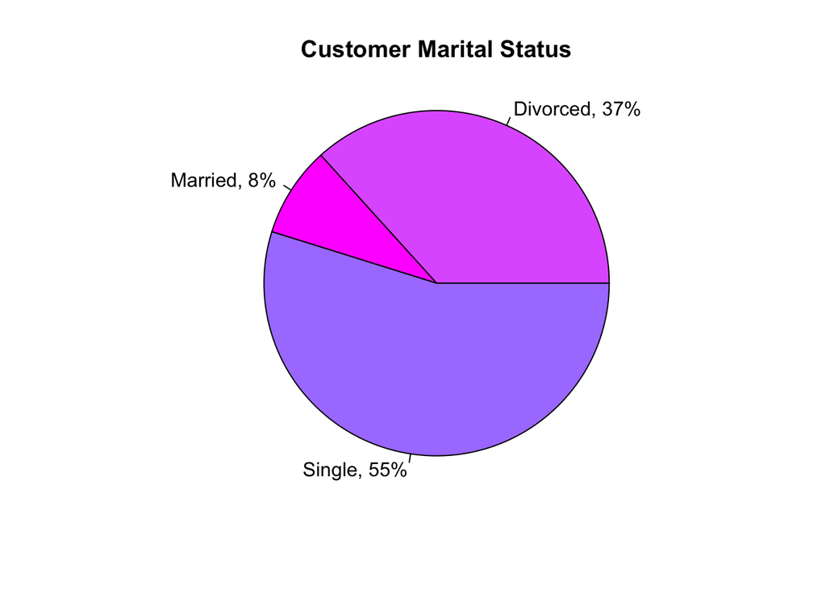

```r
slice.MS <- MSFreq$n
MS.piepercent <- 100*round(MSFreq$n/sum(MSFreq$n),2)
label<-MSFreq$`Marital Status`
label<-paste(label,",",sep="")
label<-paste(label,MS.piepercent) #default of sep=" "
label<-paste(label,"%",sep="")
pie(slice.MS,labels=label, col=c("mediumorchid1","magenta","mediumpurple1"),radius=1, main="Customer Marital Status")
```

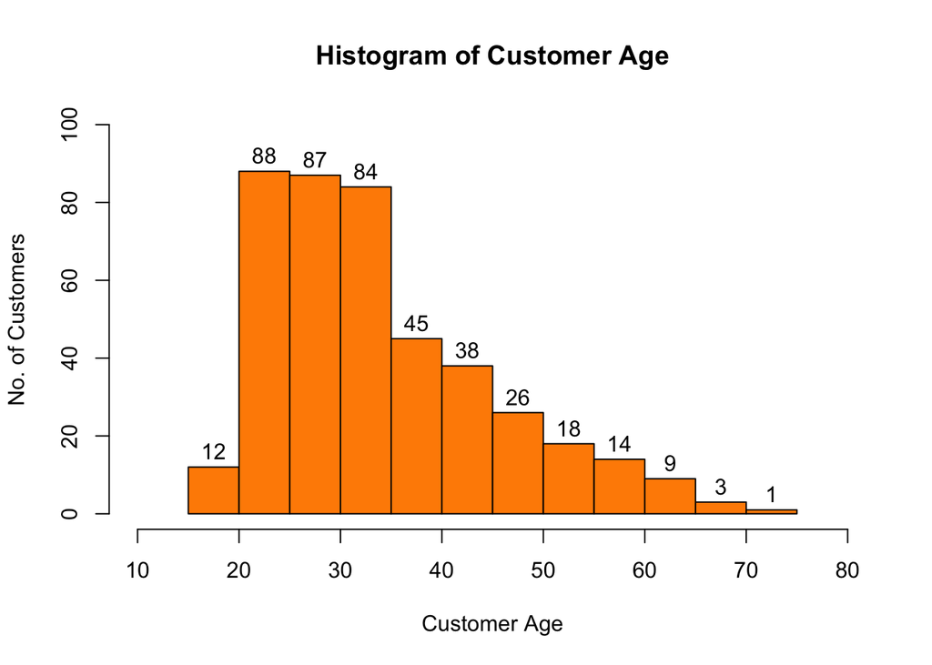

```r
#create histograms for continuous variables - age & savings
# Age
# create histogram
h1<-hist(BD$Age, main="Histogram of Customer Age",xlab="Customer Age",ylab="No. of Customers", col=c("darkorange"),xlim=c(10,80),ylim=c(0,100), labels=TRUE)
```

```r
# extract frequency table from hist()
Age.Group<-cut(BD$Age,h1$breaks)
t1<-table(Age.Group)
kable(t1, caption = "Frequency distribution by Age Group")
```

Frequency distribution by Age Group

| Age.Group | Freq |
| --- | --- |
| (15,20] | 12 |
| (20,25] | 88 |
| (25,30] | 87 |
| (30,35] | 84 |
| (35,40] | 45 |
| (40,45] | 38 |
| (45,50] | 26 |
| (50,55] | 18 |
| (55,60] | 14 |
| (60,65] | 9 |
| (65,70] | 3 |
| (70,75] | 1 |

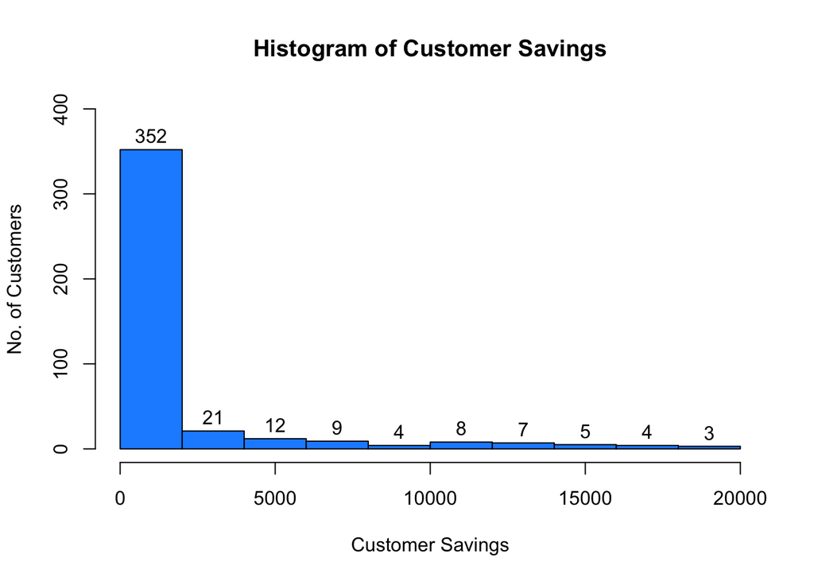

```r
# Savings
# create histogram
h2<-hist(BD$Savings, main="Histogram of Customer Savings",xlab="Customer Savings",ylab="No. of Customers", ylim=c(0,400), col=c("dodgerblue"), labels=TRUE)
```

```r
# extract frequency table from hist()
Savings.Group<-cut(BD$Savings,h2$breaks)
t2<-table(Savings.Group)
kable(t2, caption = "Frequency distribution by Savings Group")
```

Frequency distribution by Savings Group

| Savings.Group | Freq |
| --- | --- |
| (0,2e+03] | 290 |
| (2e+03,4e+03] | 21 |
| (4e+03,6e+03] | 12 |
| (6e+03,8e+03] | 9 |
| (8e+03,1e+04] | 4 |
| (1e+04,1.2e+04] | 8 |
| (1.2e+04,1.4e+04] | 7 |
| (1.4e+04,1.6e+04] | 5 |
| (1.6e+04,1.8e+04] | 4 |
| (1.8e+04,2e+04] | 3 |

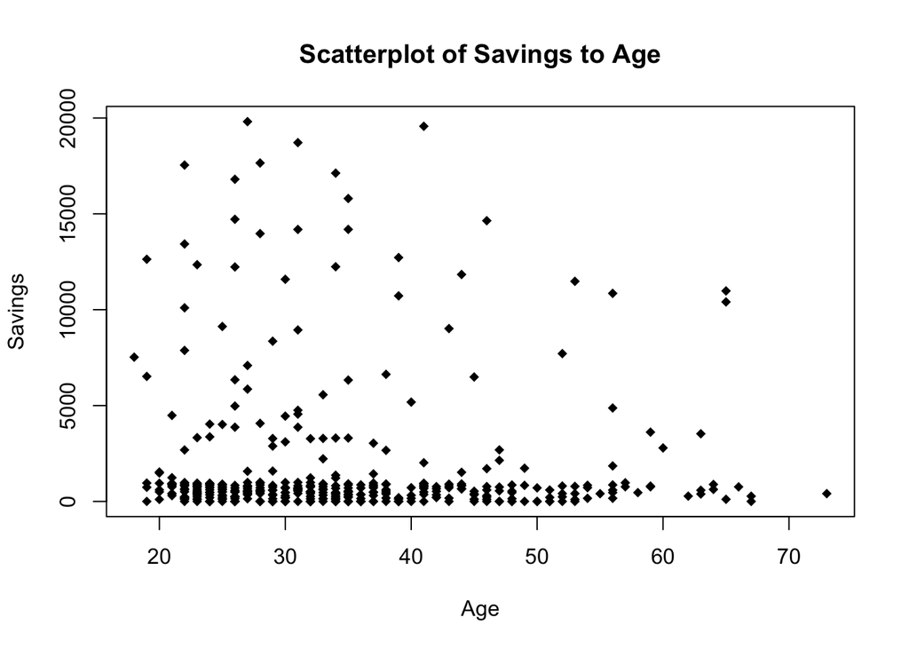

```r
#Is there any linear relationship between age and savings?
# plot a scatterplot
plot(BD$Age,BD$Savings, main="Scatterplot of Savings to Age", xlab="Age", ylab="Savings", pch=18)
```

```r
#no clear pattern btw the two variables as alot of points are cluttered at the bottom.
```

**From the scatterplot, what can we say about the relationship between Age and Savings?**

### 2) Loan Profile Dashboard

#### Purpose: To understand the frequency of loans taken by the customers

**Frequency Distribution/ Charts for Loan Purpose**

```r
LoanFreq<-BD%>%count(`Loan Purpose`)
kable(LoanFreq, caption = "Frequency Distribution for Loan Purpose")
```

Frequency Distribution for Loan Purpose

| Loan Purpose | n |
| --- | --- |
| Business | 44 |
| Education | 23 |
| Furniture | 85 |
| Large Appliance | 4 |
| New Car | 104 |
| Other | 6 |
| Repairs | 12 |
| Retraining | 2 |
| Small Appliance | 105 |
| Used Car | 40 |

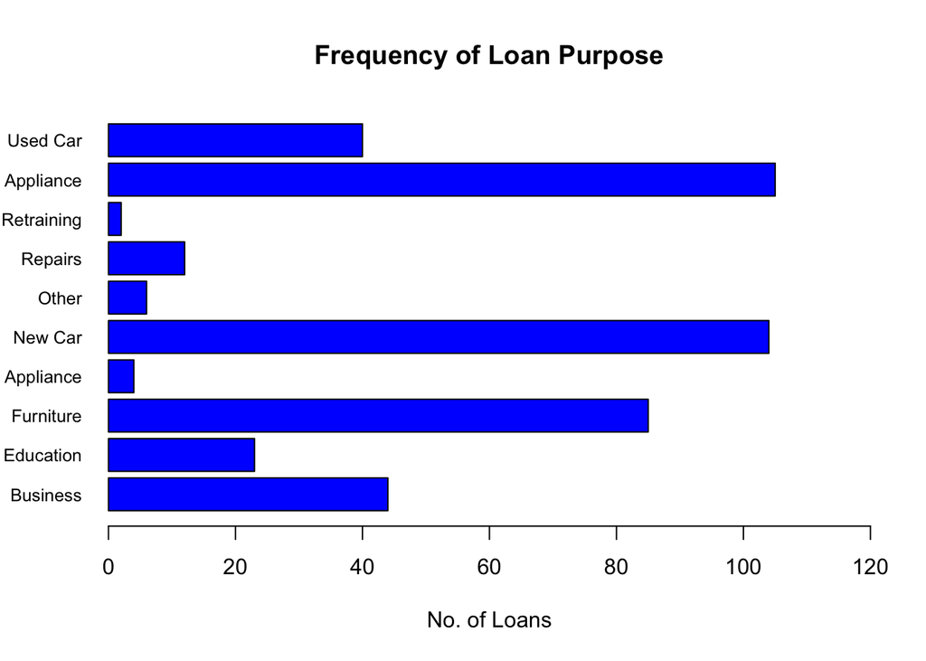

```r
Loanbar <- LoanFreq$n

# Horizontal
barplot(Loanbar,names.arg=LoanFreq$`Loan Purpose`,col="blue", main="Frequency of Loan Purpose", cex.names = 0.8, xlim=c(0,120), xlab="No. of Loans", horiz=TRUE, las=1)
```

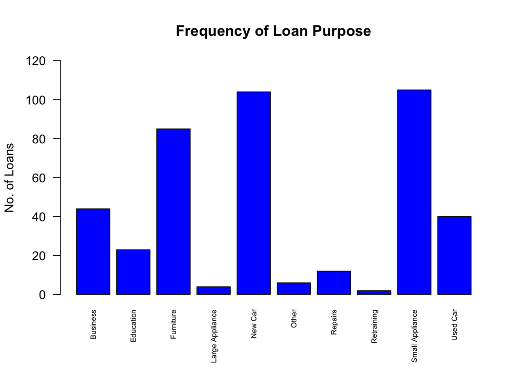

```r
# Vertical
barplot(Loanbar,names.arg=LoanFreq$`Loan Purpose`,col="blue", main="Frequency of Loan Purpose", cex.names = 0.6, ylim=c(0,120), ylab="No. of Loans", las=2)
```

**There are two options for presentation of the barchart here. Which is better?**

### 3) Loan Customer Analyses Dashboard

#### Purpose: To compare loan types across different customer profiles (e.g. gender)

```r
# Create contingency table for loan purpose and gender with gender as columns and loan purpose as rows
BD2 <- BD %>% group_by(`Loan Purpose`,Gender) %>% tally()
BD2.spread<- BD2 %>% spread(key=Gender,value=n)
BD2.spread[is.na(BD2.spread)]<-0 #convert NA to 0 value
kable(BD2.spread, caption = "Contingency table for Loan Type & Gender")
```

Contingency table for Loan Type & Gender

| Loan Purpose | F | M |
| --- | --- | --- |
| Business | 9 | 35 |
| Education | 12 | 11 |
| Furniture | 37 | 48 |
| Large Appliance | 1 | 3 |
| New Car | 34 | 70 |
| Other | 1 | 5 |
| Repairs | 4 | 8 |
| Retraining | 0 | 2 |
| Small Appliance | 32 | 73 |
| Used Car | 5 | 35 |

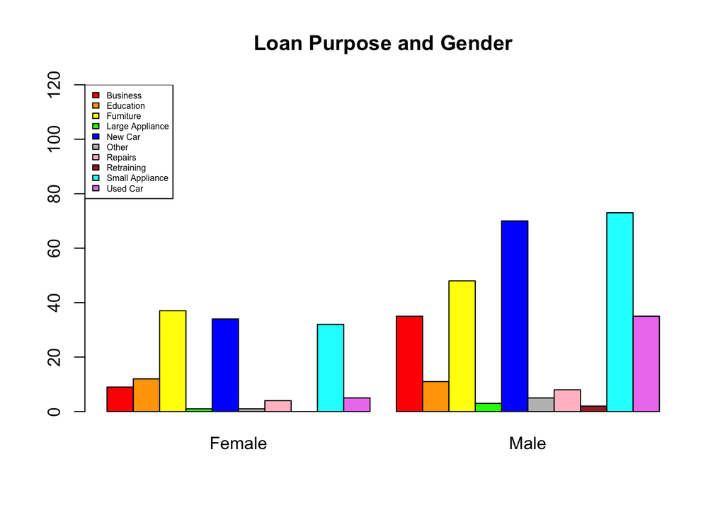

```r
#plot the grouped barplot
barmatrix<-as.matrix(BD2.spread[,c(2,3)]) #first we need to extract and convert the 2nd&3rd columns into a matrix
bar_Col<-c("red","orange","yellow","green","blue","gray","pink","brown","cyan","violet")
barplot(barmatrix,names.arg=c("Female","Male"),col=bar_Col, beside = TRUE, ylim=c(0,120), main="Loan Purpose and Gender")
legend("topleft", cex=0.5, fill=bar_Col, BD2.spread$`Loan Purpose`)
```

```r
# Create contingency table for loan purpose and gender with loan purpose as columns and gender as rows
BD3 <- BD %>% group_by(`Loan Purpose`,Gender) %>% tally()
BD3.spread<- BD3 %>% spread(key=`Loan Purpose`,value=n)
BD3.spread[is.na(BD3.spread)]<-0 #convert NA to 0 value
kable(BD3.spread, caption = "Contingency Table for Gender & Loan Purpose")
```

Contingency Table for Gender & Loan Purpose

| Gender | Business | Education | Furniture | Large Appliance | New Car | Other | Repairs | Retraining | Small Appliance | Used Car |
| --- | --- | --- | --- | --- | --- | --- | --- | --- | --- | --- |
| F | 9 | 12 | 37 | 1 | 34 | 1 | 4 | 0 | 32 | 5 |
| M | 35 | 11 | 48 | 3 | 70 | 5 | 8 | 2 | 73 | 35 |

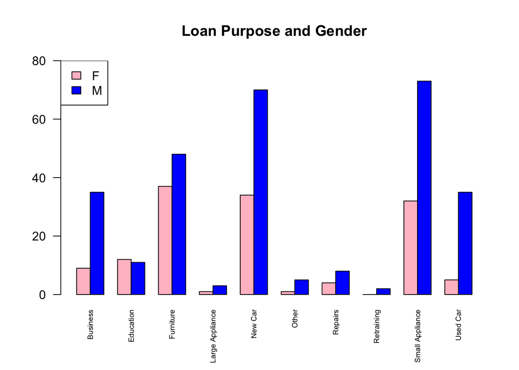

```r
#plot the grouped barplot
barmatrix.BD3<-as.matrix(BD3.spread[,c(2:11)])
barplot(barmatrix.BD3, beside = TRUE, col =c("pink","blue"), main="Loan Purpose and Gender", ylim=c(0,80), cex.names=0.6,las=2)
legend("topleft", cex=1, fill=c("pink","blue"), BD3.spread$Gender)
```

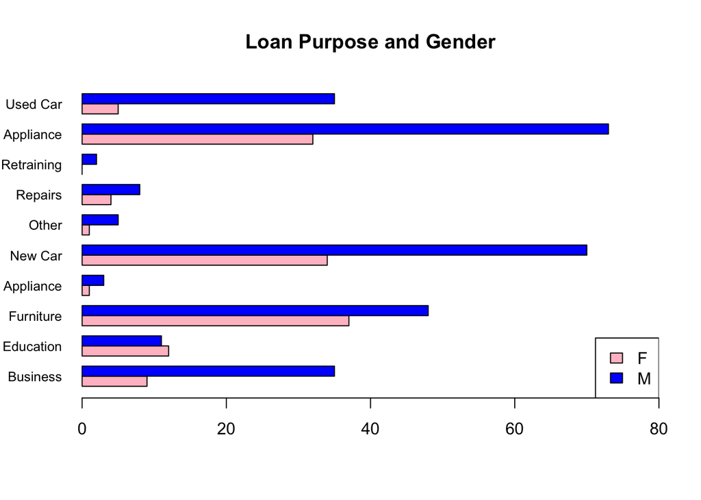

```r
# plot horizontal grouped barplot
barplot(barmatrix.BD3, beside = TRUE, horiz=TRUE, col =c("pink","blue"), main="Loan Purpose and Gender", xlim=c(0,80), cex.names=0.8, las=1)
legend("bottomright", cex=1, fill=c("pink","blue"), BD3.spread$Gender)
```

**Since both variables are categorical variables, we will use the grouped bar chart to compare frequencies across of loan types across each gender type (female and male). From the charts, we can see frequency of loans are generally higher for MALES compared to FEMALES, regardless of type of loans (except for Education).**

**Pivot Table to Compare Loan Purpose and Customer Gender and Marital Status**

```r
rpivotTable(BD, rows ="Loan Purpose", cols=c("Gender","Marital Status"),aggregatorName = "Count")
```

[interactive table not shown]

### 4) Customer Savings Analyses Dashboard

#### Purpose: To conduct pareto analyses on savings to understand if there is a small proportion of customers that contribute to significant total amount of savings with the bank

```r
#extract only the Savings column and sort in descending order
BD.sav<-BD %>% select (Savings)%>% arrange(desc(Savings))
#compute the percentage of savings over total savings
BD.sav$Percentage<-BD.sav$Savings/sum(BD.sav$Savings)
#compute cumulative percentage for Savings
BD.sav$Cumulative<-cumsum(BD.sav$Percentage)
#compute cumulative percentage of customers from top most savings
BD.sav$Cumulative.cust<-as.numeric(rownames(BD))/nrow(BD)

which(BD.sav$Cumulative>0.8)[1]
```

```
## [1] 86
```

```r
# compute percentage ofcustomers with top 80% savings
86/nrow(BD)
```

```
## [1] 0.2023529
```

**From the Pareto Analyses, we see that about 86 (out of 425) customers with largest amount of savings made up 80% of the total savings with the bank. This number amounts to about 20% of the customers in the bank.**